# Main

## Predictions

We will be investigating the same dataset as in HW1: *spambase.csv* from OpenML-100 databases. This database concerns emails, of which some were classified as spam emails (~39%), whereas the rest were work and personal emails. We will be looking at the same models trained in HW1, namely a Random Forest Classifier as well as TabPFN.

Below are a few random entries of the dataframe and predictions of different models.

| Observation | True label | RF prediction | TabPFN prediction |
| --- | --- | --- | --- |
| Observation 0 | 1 | 0.978 | 0.998 |
| Observation 1 | 0 | 0.044 | 0.002 |
| Observation 2 | 0 | 0.186 | 0.012 |
| Observation 3 | 1 | 0.957 | 0.992 |

As we can see, both RF and TabPFN have predicted the true labels correctly. TabPFN however predicts the results with very high certainty.

## LIME for observations

### Random Forest

We calculated LIME for the 4 observations outlined before. The results we aggregated and plottted on a single bar graph.

[figure not shown]

Comments:

1. Many of the variables used in the LIME explanations overlap, with a similar importance.
2. The variables are sometimes used in 2 variants (positive frequency and zero frequency) - with inverse effects.
3. The data in our dataset is sparse - the frequency of most words is 0, but it is larger for some observations. This is represented in the LIME explanations, as for example only Observation3 has a positive word frequency for *remove*, and hence only here in LIME it shows *word_freq_remove>0.00* and has a positive impact on the prediction.
4. Keeping the above points in mind, for all 4 observations the same variables are used in the explanation. The only exception is *capital_run_length_average>3.71* used only for Observation1 in place of the *word_freq_meeting* variable.

### TabPFN

We calculated LIME for the same 4 observations as before. The results we aggregated and plottted on a single bar graph.

[figure not shown]

Comments:

1. As before, many of the variables used in the LIME explanations overlap, with a similar importance.
2. As before, the variables are sometimes used in 2 variants (positive frequency and zero frequency) - with inverse effects.
3. More variables than before are not common to all 4 observations: *word_freq_85*, *char*freq*%24*, *capital_run_length_average*, *word_freq_project*, *word_freq_addresses* - this means TabPFN has a more varied importance structure, where different variables might be important to different observations.

### Comparison between RF and TabPFN

We plotted the LIME explanations for Observation0 and Observation1 of both models to check for differences

[figure not shown]

Comments:

1. Majority of the variables used in the LIME explanations overlap, but sometimes with differences in thresholds (ex. *char_freq_24 >* 0.05 vs 0.04).
2. Importances of common variables are quite varied, with TabPFN with almost double impact from most of the common variables.
3. Quite a few variables are not common among the two models, for RF: *word_freq_free*, *word_freq_000*, *word_freq_money* and for tabPFN: *word_freq_hpl*, *word_freq_telnet*, *word_freq_85*.

Below a second comparison of Observation1, which could present similar findings:

[figure not shown]

# Appendix

## Data preparation

```python
import numpy as np
import pandas as pd
import dalex as dx
import lime

spambase = pd.read_csv("spambase.csv")
```

```python
df = spambase.drop(spambase.columns[0], axis=1) #Cleaning first column which is just index
```

```python
df.describe()
```

```python
X = df.loc[:, df.columns != 'TARGET']
```

```python
y = df.loc[:, df.columns == 'TARGET']
```

```python
from sklearn.model_selection import train_test_split
X_train, X_test, y_train, y_test = train_test_split(X, y, test_size=0.1, random_state=2)
```

```python
from sklearn.model_selection import KFold
from sklearn.model_selection import cross_validate
from sklearn.metrics import accuracy_score
from sklearn.linear_model import LogisticRegression
kf = KFold(n_splits = 5)
```

## Random Forest

```python
from sklearn.ensemble import RandomForestClassifier
```

```python
RF_final = RandomForestClassifier(n_estimators=200, max_depth = 8, max_features = 0.3, random_state = 1).fit(X_train, y_train)
print("Train accuracy: ", accuracy_score(y_train, RF_final.predict(X_train)))
```

```
Train accuracy:  0.9553140096618358
```

```python
RFexplainer = dx.Explainer(RF_final, X_train, y_train)
```

```
Preparation of a new explainer is initiated

  -> data              : 4140 rows 55 cols
  -> target variable   : Parameter 'y' was a pandas.DataFrame. Converted to a numpy.ndarray.
  -> target variable   : 4140 values
  -> model_class       : sklearn.ensemble._forest.RandomForestClassifier (default)
  -> label             : Not specified, model's class short name will be used. (default)
  -> predict function  : <function yhat_proba_default at 0x00000121FDDC1550> will be used (default)
  -> predict function  : Accepts pandas.DataFrame and numpy.ndarray.
  -> predicted values  : min = 0.015, mean = 0.392, max = 0.991
  -> model type        : classification will be used (default)
  -> residual function : difference between y and yhat (default)
  -> residuals         : min = -0.896, mean = -0.00035, max = 0.945
  -> model_info        : package sklearn

A new explainer has been created!
```

```python
RFexplainer.model_performance()
```

|  | recall | precision | f1 | accuracy | auc |
| --- | --- | --- | --- | --- | --- |
| RandomForestClassifier | 0.910659 | 0.97365 | 0.941102 | 0.955314 | 0.98853 |

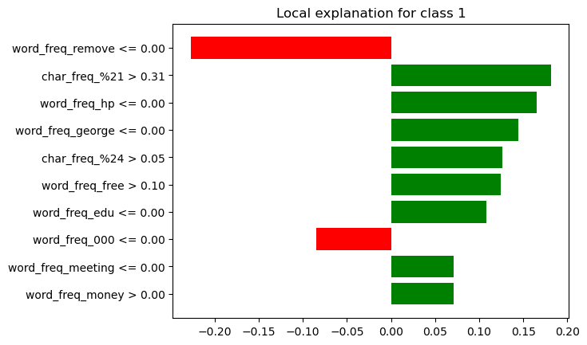

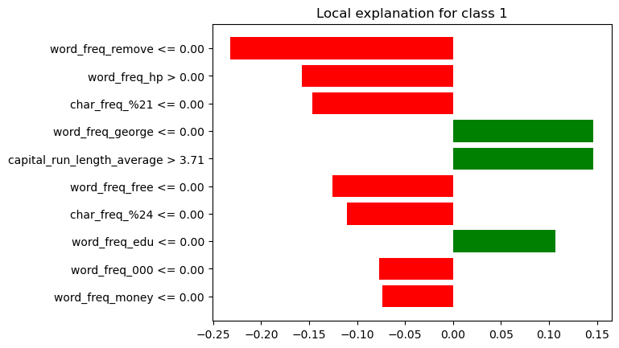

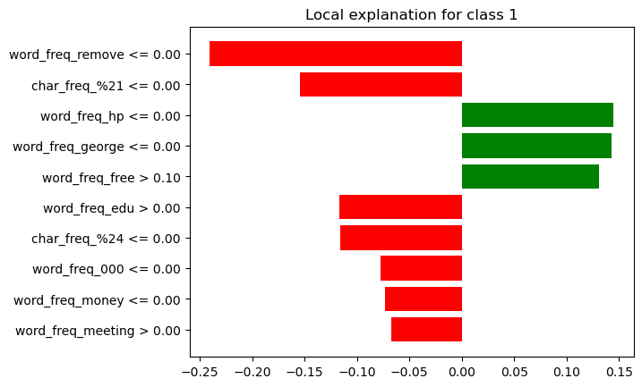

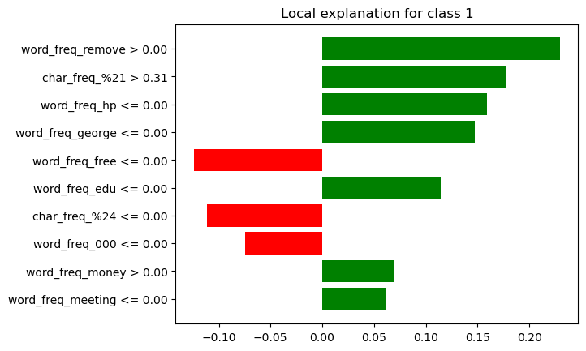

```python
RF_observations = []
RF_predictions = []
RF_explanation_results = []

for i in range(4):
    observation = X_train.iloc[[i]]
    RF_observations.append(observation)
    RF_predictions.append(RFexplainer.predict(observation))
    explanation = RFexplainer.predict_surrogate(observation)
    RF_explanation_results.append(explanation.result)
    explanation.plot()
```

```python
RF_predictions
```

```
[array([0.97818128]),
 array([0.04374682]),
 array([0.18568536]),
 array([0.9574634])]
```

```python
RF_explanation_results[0]
```

|  | variable | effect |
| --- | --- | --- |
| 0 | word_freq_remove <= 0.00 | -0.226957 |
| 1 | char_freq_%21 > 0.31 | 0.181441 |
| 2 | word_freq_hp <= 0.00 | 0.165038 |
| 3 | word_freq_george <= 0.00 | 0.144213 |
| 4 | char_freq_%24 > 0.05 | 0.126504 |
| 5 | word_freq_free > 0.10 | 0.124456 |
| 6 | word_freq_edu <= 0.00 | 0.108421 |
| 7 | word_freq_000 <= 0.00 | -0.084501 |
| 8 | word_freq_meeting <= 0.00 | 0.071288 |
| 9 | word_freq_money > 0.00 | 0.070635 |

```python
from functools import reduce
def merge_dataframes(left, right):
    return pd.merge(left, right, on='variable', how='outer')

merged_df = reduce(merge_dataframes, RF_explanation_results)

merged_df.columns = ['variable']+['effect_obs' + str(i) for i in range(len(RF_explanation_results))]

#merged_df.fillna(0, inplace=True)
merged_df = merged_df.set_index(['variable'])
print(merged_df)
```

```
                                   effect_obs0  effect_obs1  effect_obs2  \
variable
word_freq_remove <= 0.00             -0.226957    -0.231920    -0.240599
char_freq_%21 > 0.31                  0.181441          NaN          NaN
word_freq_hp <= 0.00                  0.165038          NaN     0.144893
word_freq_george <= 0.00              0.144213     0.146362     0.143021
char_freq_%24 > 0.05                  0.126504          NaN          NaN
word_freq_free > 0.10                 0.124456          NaN     0.131129
word_freq_edu <= 0.00                 0.108421     0.106524          NaN
word_freq_000 <= 0.00                -0.084501    -0.077171    -0.077861
word_freq_meeting <= 0.00             0.071288          NaN          NaN
word_freq_money > 0.00                0.070635          NaN          NaN
word_freq_hp > 0.00                        NaN    -0.157731          NaN
char_freq_%21 <= 0.00                      NaN    -0.146438    -0.154352
capital_run_length_average > 3.71          NaN     0.146070          NaN
word_freq_free <= 0.00                     NaN    -0.125200          NaN
char_freq_%24 <= 0.00                      NaN    -0.110615    -0.115793
word_freq_money <= 0.00                    NaN    -0.073757    -0.073069
word_freq_edu > 0.00                       NaN          NaN    -0.116538
word_freq_meeting > 0.00                   NaN          NaN    -0.067509
word_freq_remove > 0.00                    NaN          NaN          NaN

                                   effect_obs3
variable
word_freq_remove <= 0.00                   NaN
char_freq_%21 > 0.31                  0.177466
word_freq_hp <= 0.00                  0.159338
word_freq_george <= 0.00              0.147410
char_freq_%24 > 0.05                       NaN
word_freq_free > 0.10                      NaN
word_freq_edu <= 0.00                 0.114476
word_freq_000 <= 0.00                -0.074879
word_freq_meeting <= 0.00             0.062085
word_freq_money > 0.00                0.069119
word_freq_hp > 0.00                        NaN
char_freq_%21 <= 0.00                      NaN
capital_run_length_average > 3.71          NaN
word_freq_free <= 0.00               -0.123895
char_freq_%24 <= 0.00                -0.111041
word_freq_money <= 0.00                    NaN
word_freq_edu > 0.00                       NaN
word_freq_meeting > 0.00                   NaN
word_freq_remove > 0.00               0.229512
```

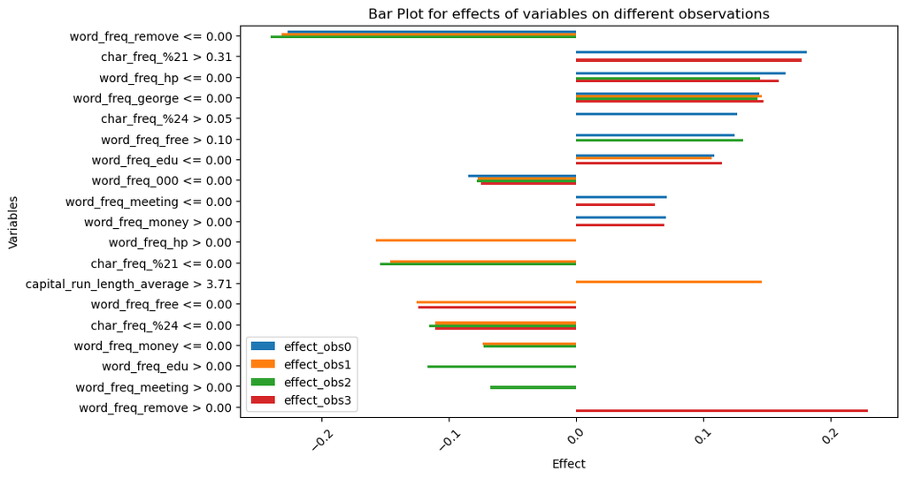

```python
import matplotlib.pyplot as plt
merged_df.plot(kind='barh', figsize=(10, 6))
plt.xlabel('Effect')
plt.ylabel('Variables')
plt.title('Bar Plot for effects of variables on different observations')
plt.xticks(rotation=45)
plt.gca().invert_yaxis()
plt.show()
```

```python
X_train.iloc[[0,1,2,3]]
```

|  | word_freq_make | word_freq_address | word_freq_all | word_freq_3d | word_freq_our | word_freq_over | word_freq_remove | word_freq_internet | word_freq_order | word_freq_mail | ... | word_freq_edu | word_freq_table | word_freq_conference | char_freq_%3B | char_freq_%28 | char_freq_%5B | char_freq_%21 | char_freq_%24 | char_freq_%23 | capital_run_length_average |
| --- | --- | --- | --- | --- | --- | --- | --- | --- | --- | --- | --- | --- | --- | --- | --- | --- | --- | --- | --- | --- | --- |
| 1552 | 0.44 | 0.0 | 0.0 | 0.0 | 0.89 | 0.0 | 0.0 | 0.0 | 0.0 | 0.44 | ... | 0.00 | 0.0 | 0.0 | 0.000 | 0.000 | 0.0 | 1.131 | 0.15 | 0.075 | 2.428 |
| 3969 | 0.00 | 0.0 | 1.0 | 0.0 | 0.00 | 0.0 | 0.0 | 0.0 | 0.0 | 0.25 | ... | 0.00 | 0.0 | 1.0 | 0.457 | 0.294 | 0.0 | 0.000 | 0.00 | 0.000 | 4.379 |
| 4373 | 0.97 | 0.0 | 0.0 | 0.0 | 0.48 | 0.0 | 0.0 | 0.0 | 0.0 | 0.00 | ... | 0.97 | 0.0 | 0.0 | 0.000 | 0.150 | 0.0 | 0.000 | 0.00 | 0.075 | 3.367 |
| 538 | 0.90 | 0.0 | 0.0 | 0.0 | 0.00 | 0.0 | 0.9 | 0.0 | 0.0 | 0.00 | ... | 0.00 | 0.0 | 0.0 | 0.000 | 0.000 | 0.0 | 0.537 | 0.00 | 0.000 | 2.782 |

4 rows × 55 columns

```python
y_train.iloc[[0,1,2,3]]
```

|  | TARGET |
| --- | --- |
| 1552 | 1 |
| 3969 | 0 |
| 4373 | 0 |
| 538 | 1 |

## TabPFN

```python
from tabpfn import TabPFNClassifier
```

```python
tabpfn_final = TabPFNClassifier(device='cpu', N_ensemble_configurations=32).fit(X_train[:1000], y_train[:1000])
print("Train accuracy: ", accuracy_score(y_train[:1000], tabpfn_final.predict(X_train[:1000])))
```

```
Loading model that can be used for inference only
Using a Transformer with 25.82 M parameters
```

```
Train accuracy:  0.987
```

```python
TabPFNexplainer = dx.Explainer(tabpfn_final, X_train[:1000], y_train[:1000])
```

```
Preparation of a new explainer is initiated

  -> data              : 1000 rows 55 cols
  -> target variable   : Parameter 'y' was a pandas.DataFrame. Converted to a numpy.ndarray.
  -> target variable   : 1000 values
  -> model_class       : tabpfn.scripts.transformer_prediction_interface.TabPFNClassifier (default)
  -> label             : Not specified, model's class short name will be used. (default)
  -> predict function  : <function yhat_proba_default at 0x00000121FDDC1550> will be used (default)
  -> predict function  : Accepts pandas.DataFrame and numpy.ndarray.
  -> predicted values  : min = 3.46e-06, mean = 0.408, max = 1.0
  -> model type        : classification will be used (default)
  -> residual function : difference between y and yhat (default)
  -> residuals         : min = -0.556, mean = 0.00229, max = 0.941
  -> model_info        : package tabpfn

A new explainer has been created!
```

```python
TabPFNexplainer.model_performance()
```

|  | recall | precision | f1 | accuracy | auc |
| --- | --- | --- | --- | --- | --- |
| TabPFNClassifier | 0.973171 | 0.995012 | 0.98397 | 0.987 | 0.99853 |

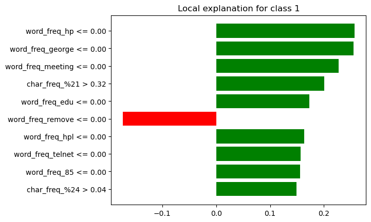

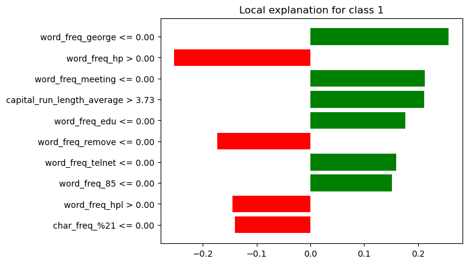

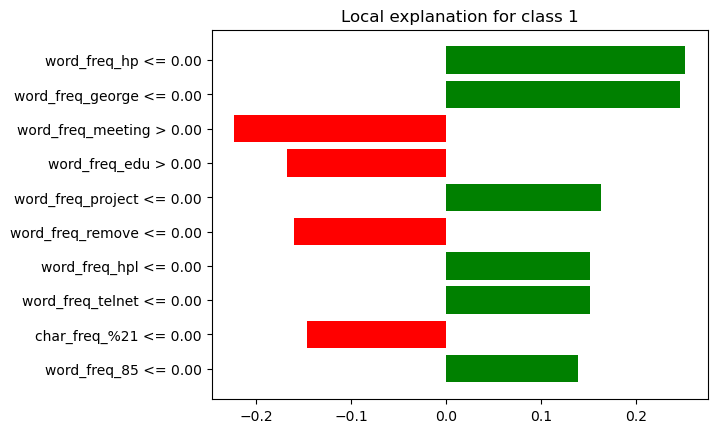

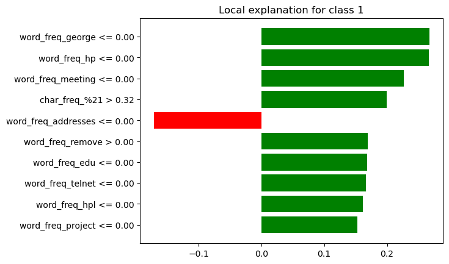

```python
TabPFN_observations = []
TabPFN_predictions = []
TabPFN_explanation_results = []

for i in range(4):
    observation = X_train.iloc[[i]]
    TabPFN_observations.append(observation)
    TabPFN_predictions.append(TabPFNexplainer.predict(observation))
    explanation = TabPFNexplainer.predict_surrogate(observation)
    TabPFN_explanation_results.append(explanation.result)
    explanation.plot()
```

```python
TabPFN_merged_df = reduce(merge_dataframes, TabPFN_explanation_results)

TabPFN_merged_df.columns = ['variable']+['effect_obs' + str(i) for i in range(len(TabPFN_explanation_results))]

#merged_df.fillna(0, inplace=True)
TabPFN_merged_df = TabPFN_merged_df.set_index(['variable'])
print(TabPFN_merged_df)
```

[output not shown]

```
                                   effect_obs0  effect_obs1  effect_obs2  \
variable
word_freq_hp <= 0.00                  0.256777          NaN     0.252153
word_freq_george <= 0.00              0.254794     0.257051     0.246358
word_freq_meeting <= 0.00             0.227018     0.213074          NaN
char_freq_%21 > 0.32                  0.200285          NaN          NaN
word_freq_edu <= 0.00                 0.173318     0.176945          NaN
word_freq_remove <= 0.00             -0.173297    -0.172636    -0.160523
word_freq_hpl <= 0.00                 0.163354          NaN     0.152248
word_freq_telnet <= 0.00              0.156618     0.159945     0.151516
word_freq_85 <= 0.00                  0.155622     0.151909     0.138983
char_freq_%24 > 0.04                  0.149381          NaN          NaN
word_freq_hp > 0.00                        NaN    -0.253190          NaN
capital_run_length_average > 3.73          NaN     0.211375          NaN
word_freq_hpl > 0.00                       NaN    -0.145285          NaN
char_freq_%21 <= 0.00                      NaN    -0.140405    -0.146655
word_freq_meeting > 0.00                   NaN          NaN    -0.223394
word_freq_edu > 0.00                       NaN          NaN    -0.168028
word_freq_project <= 0.00                  NaN          NaN     0.163417
word_freq_addresses <= 0.00                NaN          NaN          NaN
word_freq_remove > 0.00                    NaN          NaN          NaN

                                   effect_obs3
variable
word_freq_hp <= 0.00                  0.266652
word_freq_george <= 0.00              0.267262
word_freq_meeting <= 0.00             0.226467
char_freq_%21 > 0.32                  0.199905
word_freq_edu <= 0.00                 0.168346
word_freq_remove <= 0.00                   NaN
word_freq_hpl <= 0.00                 0.161733
word_freq_telnet <= 0.00              0.166105
word_freq_85 <= 0.00                       NaN
char_freq_%24 > 0.04                       NaN
word_freq_hp > 0.00                        NaN
capital_run_length_average > 3.73          NaN
word_freq_hpl > 0.00                       NaN
char_freq_%21 <= 0.00                      NaN
word_freq_meeting > 0.00                   NaN
word_freq_edu > 0.00                       NaN
word_freq_project <= 0.00             0.153044
word_freq_addresses <= 0.00          -0.171186
word_freq_remove > 0.00               0.169113
```

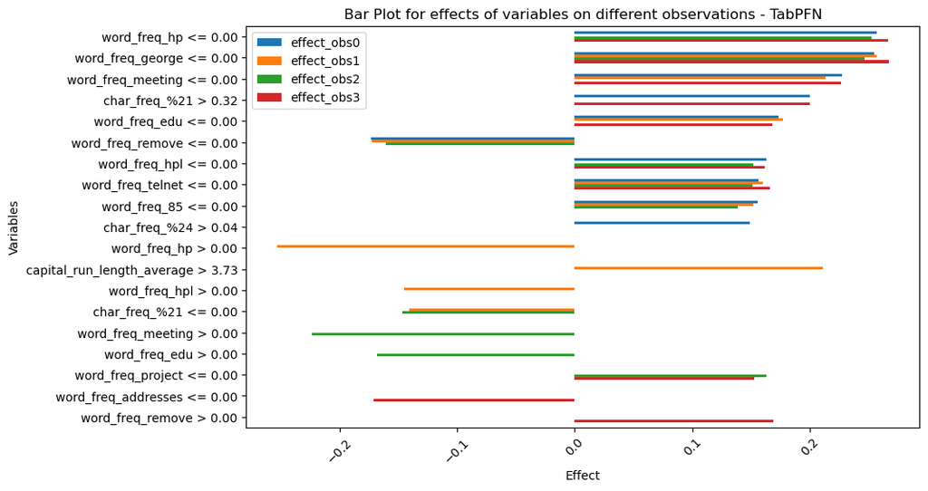

```python
TabPFN_merged_df.plot(kind='barh', figsize=(10, 6))
plt.xlabel('Effect')
plt.ylabel('Variables')
plt.title('Bar Plot for effects of variables on different observations - TabPFN')
plt.xticks(rotation=45)
plt.gca().invert_yaxis()
plt.show()
```

```python
TabPFN_predictions
```

```
[array([0.99750036], dtype=float32),
 array([0.00162567], dtype=float32),
 array([0.01215665], dtype=float32),
 array([0.992057], dtype=float32)]
```

## Comparison: RF vs TabPFN

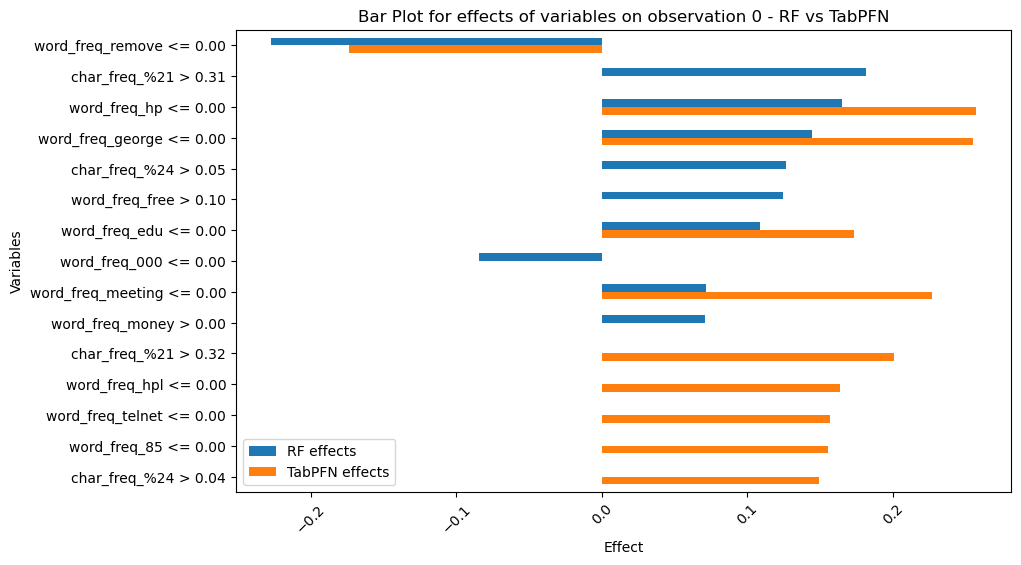

```python
Comp0_merged_df = reduce(merge_dataframes, [RF_explanation_results[0], TabPFN_explanation_results[0]])
Comp0_merged_df.columns = ['variable', 'RF effects', 'TabPFN effects']

#merged_df.fillna(0, inplace=True)
Comp0_merged_df = Comp0_merged_df.set_index(['variable'])
Comp0_merged_df.plot(kind='barh', figsize=(10, 6))
plt.xlabel('Effect')
plt.ylabel('Variables')
plt.title('Bar Plot for effects of variables on observation 0 - RF vs TabPFN')
plt.xticks(rotation=45)
plt.gca().invert_yaxis()
plt.show()
```

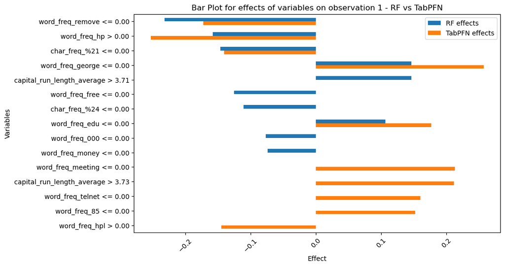

```python
Comp1_merged_df = reduce(merge_dataframes, [RF_explanation_results[1], TabPFN_explanation_results[1]])
Comp1_merged_df.columns = ['variable', 'RF effects', 'TabPFN effects']

#merged_df.fillna(0, inplace=True)
Comp1_merged_df = Comp1_merged_df.set_index(['variable'])
Comp1_merged_df.plot(kind='barh', figsize=(10, 6))
plt.xlabel('Effect')
plt.ylabel('Variables')
plt.title('Bar Plot for effects of variables on observation 1 - RF vs TabPFN')
plt.xticks(rotation=45)
plt.gca().invert_yaxis()
plt.show()
```